# Bayesian Inference for Simple Linear Regression (Ch.14), Part II

AG Schissler

04/01/2020

## We discussed the joint likelihood of $\beta$ and $\alpha_{\bar{x}}$ last time (see Section 14.4).

Some Questions for the group:

- Starting from a normal model for the data $y|x$, what distributions do $\beta$ and $\alpha_{\bar{x}}$ follow?
- How do we know the two regression parameters (coefficients) behave independently in the joint likelihood?
- Why does $Var(\alpha_{\bar{x}})=\sigma^2/n$? Why should that agree with our intuition about the quantity?

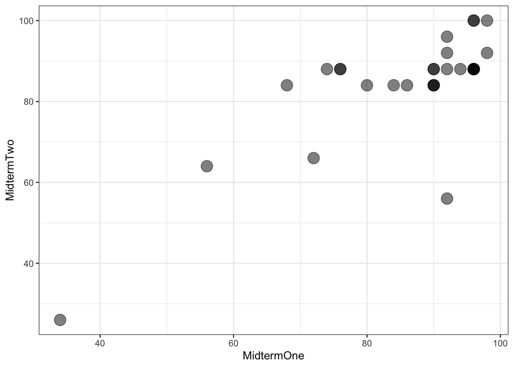

```r
### load scrambled midterm one and midterm three scores
reg_data <- readRDS("data/exam_reg_data.rds")

## visualize relationship
p0 <- ggplot(data = reg_data, mapping =  aes(x = MidtermOne, y = MidtermTwo))
p1 <- p0 + geom_point(alpha = 0.5, size = 5)
p1
```

```r
### explore numerically
(x_bar <- mean(reg_data$MidtermOne))
```

```
## [1] 85.72414
```

```r
(y_bar <- mean(reg_data$MidtermTwo))
```

```
## [1] 84
```

```r
xy_bar <- mean(reg_data$MidtermOne * reg_data$MidtermTwo)
x2_bar <- mean(reg_data$MidtermOne^2)
x_bar2 <- mean(reg_data$MidtermOne)^2
```

### Compute the least squares estimates of $\alpha_0, \beta$ and $\alpha_{\overline{x}}$.

for the equations, $\mu_{y|x} = \alpha_0 + \beta x$ or, equivalently, $\mu_{y|x} = \alpha_{\overline{x}} + \beta \left( x - \overline{x} \right)$.

### Now let’s compute the variance estimator

$\hat{\sigma^2} = \frac{\sum_{i=1}^n (y_i - \hat{y_i})^2}{n-2}$.

```r
compute_simple_ls <- function(x, y) {
    B <- ( mean(x*y) - mean(x) * mean(y) ) / ( mean(x^2) - mean(x)^2  )
    A0 <- mean(y) - B * mean(x)
    return( list(A0 = A0, B = B) )
}

my_ls_soln <- compute_simple_ls(x = reg_data$MidtermOne, y = reg_data$MidtermTwo)

## Development values
## x <- reg_data$MidtermOne
## y <- reg_data$MidtermTwo

compute_sigma_hat <- function(x, y){
    ls_estimator <- compute_simple_ls(x = x, y = y)
    y_hat <- ls_estimator$A0 + ls_estimator$B * x
    ## variance estimator
    sqrt( sum( (y - y_hat)^2 ) / ( length(x) - 2 ) )
}

compute_sigma_hat(x = reg_data$MidtermOne, y = reg_data$MidtermTwo)
```

```
## [1] 9.551624
```

```r
summary(lm(MidtermTwo ~ MidtermOne, data = reg_data))
```

```
##
## Call:
## lm(formula = MidtermTwo ~ MidtermOne, data = reg_data)
##
## Residuals:
##     Min      1Q  Median      3Q     Max
## -32.980  -4.154  -0.219   6.259  14.065
##
## Coefficients:
##             Estimate Std. Error t value Pr(>|t|)
## (Intercept)  15.9757    10.9134   1.464    0.155
## MidtermOne    0.7935     0.1256   6.317 9.22e-07 ***
## ---
## Signif. codes:  0 '***' 0.001 '**' 0.01 '*' 0.05 '.' 0.1 ' ' 1
##
## Residual standard error: 9.552 on 27 degrees of freedom
## Multiple R-squared:  0.5964, Adjusted R-squared:  0.5815
## F-statistic: 39.91 on 1 and 27 DF,  p-value: 9.215e-07
```

```r
ssx <- sum( (reg_data$MidtermOne - mean(reg_data$MidtermOne))^2 )
```

## II. Prior specification in Bayes Theorem for the regression model (14.4 part II; 20 - 25 min)

Now that we have analyzed joint likelihood for $\beta$ and $\alpha_{\bar{x}}$, we select the form of the prior.

### We’ll assume independent for the joint prior for $\beta$ and $\alpha_{\bar{x}}$.

$g(\alpha_{\overline{x}}, \beta) = g(\alpha_{\overline{x}}) \times g(\beta)$.

The independence assumption simplifies the calculation (not required, but it is reasonable). To get closed-form updating rules for the posterior, choose either a flat prior (which is also Jeffrey’s prior in the normal model) or a normal prior for each parameter.

- To choose a prior $g$ for $\alpha_{\overline{x}}$, the analyst to needs to guess at the mean of $y$ and its variation. Bolstad suggests
1. Pick a prior mean $m_{a_x}$ for $\alpha_{\overline{x}}$.
2. Guess lower and upper bounds for $m_{a_x}$.
3. Divide the range of your bounds by 6 (since we have a normal model) to estimate your prior standard deviation $s_{a_x}$.
- Usually we are more interested in the slope $\beta$. To set a prior $g(\beta)$,
1. Select a viewpoint. A default viewpoint and widely accepted is to assume $m_\beta=0$, that there is no relationship between the variables. But one could have different prior beliefs that are pessimistic or optimistic.
2. Then think about the possible range values of the slope, the corresponding change in $y$ for a unit change in $x$.
3. Divide the range of your bounds by 6 (since we have a normal model) to estimate your prior standard deviation $s_\beta$.

## III. The joint posterior for $\beta$ and $\alpha_{\overline{x}}$ (14.5; 15 - 20 min)

Now that we have the prior and likelihood specified. Let’s get that Bayesian posterior and complete our inference!

### Walk through Section 14.4

### Updating rules under a normal prior

See text equations 14.7, 14.8 and the two equations below them for the updating rules.

### Let’s find the posterior

Assume unknown variance.

```r
Bolstad::bayes.lin.reg(y = reg_data$MidtermTwo, x = reg_data$MidtermOne, slope.prior = "flat", intcpt.prior = "flat", plot.data = TRUE)
```

```
## Standard deviation of residuals:  9.55
```

```
##             Posterior Mean Posterior Std. Deviation
##             -------------- ------------------------
## Intercept:  84             1.7737
## Slope:      0.7935         0.12562
```

```
## Standard deviation of residuals:  9.55
```

```
##             Posterior Mean Posterior Std. Deviation
##             -------------- ------------------------
## Intercept:  82.96          1.5268
## Slope:      0.3078         0.078236
```

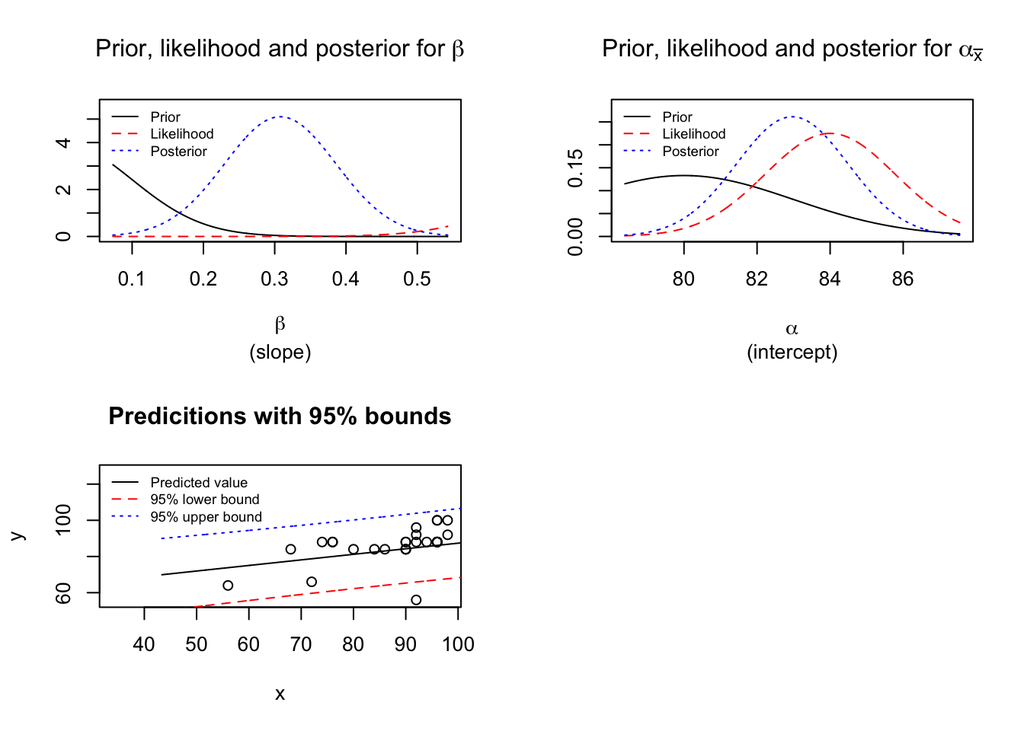

```r
## skeptical prior
mb0 <- 0
sb0 <- 1/10
ma0 <- 80
sa0 <- 3

bayes.lin.reg(y = reg_data$MidtermTwo, x = reg_data$MidtermOne, slope.prior = "normal", intcpt.prior = "normal", mb0=mb0, sb0=sb0, ma0=ma0, sa0=sa0, plot.data = TRUE)
```

```
## Standard deviation of residuals:  9.55
```

```
##             Posterior Mean Posterior Std. Deviation
##             -------------- ------------------------
## Intercept:  83.88          1.7464
## Slope:      0.7921         0.12551
```

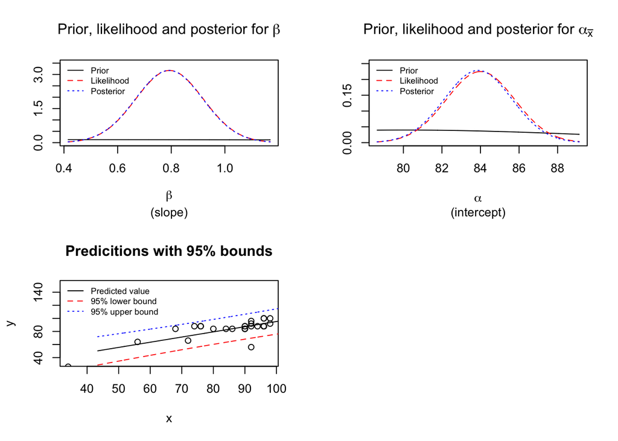

```r
## WIP prior
mb0 <- 0
sb0 <- 3
ma0 <- 80
sa0 <- 10

bayes.lin.reg(y = reg_data$MidtermTwo, x = reg_data$MidtermOne, slope.prior = "normal", intcpt.prior = "normal", mb0=mb0, sb0=sb0, ma0=ma0, sa0=sa0, plot.data = TRUE)
```

## III. Credible intervals and hypothesis testing (14.5; 10 - 15 min)

### Bayesian credible interval around the slope

Just normal model here. Please find a 95% credible interval under your priors with unknown variance.

### Frequentist credible interval around the slope

$\hat{\beta} \pm t_{\alpha/2,df=n-2} \frac{\hat{\sigma}}{\sqrt{SS_x}}$.

```r
fit <- Bolstad::bayes.lin.reg(y = reg_data$MidtermTwo, x = reg_data$MidtermOne, slope.prior = "flat", intcpt.prior = "flat", plot.data = TRUE)
```

```
## Standard deviation of residuals:  9.55
```

```
##             Posterior Mean Posterior Std. Deviation
##             -------------- ------------------------
## Intercept:  84             1.7737
## Slope:      0.7935         0.12562
```

```r
## An 1-alpha% confidence interval
## str(fit)
alpha = 0.11
df <- nrow(reg_data) - 2
t_star <- qt( p = alpha / 2, df = df, lower.tail = FALSE)
c(fit$post.coef[2] - t_star * fit$post.coef.sd[2], fit$post.coef[2] + t_star * fit$post.coef.sd[2])
```

```
## [1] 0.5859346 1.0011163
```

```r
## from lm()
alpha = 0.11
lm_summ <- summary(lm(MidtermTwo ~ MidtermOne, reg_data, alpha = alpha))
c("lower" = lm_summ$coef[2,1] - qt(1-alpha/2, df = lm_summ$df[2]) * lm_summ$coef[2, 2],
  "upper" = lm_summ$coef[2,1] + qt(1-alpha/2, df = lm_summ$df[2]) * lm_summ$coef[2, 2])
```

```
##     lower     upper
## 0.5859346 1.0011163
```

```r
## This doesn't use a t distribution (assumes known variance).
quantile(fit$slope, probs = c(alpha / 2, 1 - alpha/2) )
```

[output not shown]

```r
fit$slope
```

[output not shown]

[output cut: 682 more lines]

### Testing One-sided hypothesis about slope

Please test whether the slope is larger than 0 and be prepared to share your screen.

```r
fit <- Bolstad::bayes.lin.reg(y = reg_data$MidtermTwo, x = reg_data$MidtermOne, slope.prior = "flat", intcpt.prior = "flat", plot.data = TRUE)
```

```
## Standard deviation of residuals:  9.55
```

```
##             Posterior Mean Posterior Std. Deviation
##             -------------- ------------------------
## Intercept:  84             1.7737
## Slope:      0.7935         0.12562
```

```r
pnorm(0, mean = fit$post.coef[2], sd = fit$post.coef.sd[2], lower.tail = TRUE)
```

```
## [1] 1.332943e-10
```

```r
pt( (fit$post.coef[2] - 0) / fit$post.coef.sd[2], df = nrow(reg_data) - 2, lower.tail = FALSE)
```

```
## [1] 4.607737e-07
```

### Testing Two-sided hypothesis about slope

Please test whether the slope is different from 0.

## IV. Predictive ditribution for the regression model (14.5; 10 - 15 min)

### Finding the predictive distribution

Discuss the derivation.

### predictive distribution parameters

Please find the predictive distribution under your prior and unknown variance.

1. Find the predictive density when a student scores a 70 on the first exam. Use either Equations 14.13, 14.14 or `bayes.lin.reg`.

```r
Bolstad::bayes.lin.reg(y = reg_data$MidtermTwo, x = reg_data$MidtermOne, slope.prior = "flat", intcpt.prior = "flat", plot.data = TRUE, pred.x = 70)
```

```
## Standard deviation of residuals:  9.55
```

```
##             Posterior Mean Posterior Std. Deviation
##             -------------- ------------------------
## Intercept:  84             1.7737
## Slope:      0.7935         0.12562
```

```
## x       Predicted y  SE
## ------  -----------  -----------
## 70        71.52        9.9137
```

2. Find a 95% prediction interval

## Closing (5 min)

- Enter into the chat your own answer to the guiding question, “How well does Midterm One scores predict Midterm Two?”
- Share.